```python
import pandas as pd
import numpy as np
import nltk
from nltk.corpus import stopwords
from nltk.tokenize import word_tokenize
import string
import re
from sklearn.feature_extraction.text import TfidfVectorizer
from sklearn.feature_extraction.text import CountVectorizer
from sklearn.model_selection import train_test_split
from sklearn.naive_bayes import MultinomialNB
from sklearn.linear_model import LogisticRegression
from sklearn.metrics import classification_report
import matplotlib.pyplot as plt
from wordcloud import WordCloud
nltk.download('punkt')
nltk.download('stopwords')
```

```
True
```

# Importiamo il dataset

```python
data_set = pd.read_csv("C:/Users/massi/OneDrive/Desktop/Classificare i reclami dei consumatori con python e il Machine Learning/Lamentele_sample.csv")
```

# Visualizziamo le prime osservazioni del data_set

```python
data_set.head()
```

|  | Unnamed: 0 | Date received | Product | Sub-product | Issue | Sub-issue | Consumer complaint narrative |
| --- | --- | --- | --- | --- | --- | --- | --- |
| 0 | 2686509 | 2021-10-04 | Credit reporting, credit repair services, or o... | Credit reporting | Improper use of your report | Reporting company used your report improperly | NaN |
| 1 | 2107155 | 2017-01-19 | Student loan | Federal student loan servicing | Dealing with my lender or servicer | Received bad information about my loan | In 2009 I got married and changed my last name... |
| 2 | 1116803 | 2018-01-31 | Credit reporting, credit repair services, or o... | Credit reporting | Unable to get your credit report or credit score | Problem getting your free annual credit report | NaN |
| 3 | 299024 | 2022-03-16 | Credit reporting, credit repair services, or o... | Credit reporting | Problem with a credit reporting company's inve... | Their investigation did not fix an error on yo... | NaN |
| 4 | 4251 | 2022-11-03 | Credit reporting, credit repair services, or o... | Credit reporting | Improper use of your report | Reporting company used your report improperly | NaN |

# Dimensioni del data_set -> Numero di righe x Numero di colonne

```python
data_set.shape
```

```
(10000, 7)
```

# Visualizziamo la struttura del data_set

```python
data_set.info()
```

```
<class 'pandas.core.frame.DataFrame'>
RangeIndex: 10000 entries, 0 to 9999
Data columns (total 7 columns):
 #   Column                        Non-Null Count  Dtype
---  ------                        --------------  -----
 0   Unnamed: 0                    10000 non-null  int64
 1   Date received                 10000 non-null  object
 2   Product                       10000 non-null  object
 3   Sub-product                   9248 non-null   object
 4   Issue                         10000 non-null  object
 5   Sub-issue                     7797 non-null   object
 6   Consumer complaint narrative  3619 non-null   object
dtypes: int64(1), object(6)
memory usage: 547.0+ KB
```

# Notiamo la presenza di valori Mancanti (NA)

# Rimuoviamo tali valori dal data_set

```python
data_set_clean = data_set.dropna()
```

```python
data_set_clean.shape
```

```
(2905, 7)
```

# Le features di interesse sono: Product e Consumer complaint narrative

```python
data_set_product_narrative = data_set_clean[['Product',  'Consumer complaint narrative']].reset_index(drop=True)
```

```python
data_set_product_narrative
```

|  | Product | Consumer complaint narrative |
| --- | --- | --- |
| 0 | Student loan | In 2009 I got married and changed my last name... |
| 1 | Debt collection | This agency is calling repeated times during t... |
| 2 | Credit reporting, credit repair services, or o... | The account for XXXX/XXXX-XXXX-XXXX, in which,... |
| 3 | Credit reporting, credit repair services, or o... | Department of Education/ XXXX XXXX XXXX XXXX X... |
| 4 | Credit reporting, credit repair services, or o... | On XXXX/XXXX/XXXX I gave permission for a cred... |
| ... | ... | ... |
| 2900 | Credit reporting, credit repair services, or o... | I am a victim of identity theft, I have been p... |
| 2901 | Checking or savings account | I have regions bank - life green checking acco... |
| 2902 | Credit reporting, credit repair services, or o... | 15usc1681b no permission to place on consumer ... |
| 2903 | Credit reporting, credit repair services, or o... | I have been requesting information from the bu... |
| 2904 | Credit reporting, credit repair services, or o... | IHello Im writing to you because my student lo... |

2905 rows × 2 columns

# In questo caso, per ogni prodotto abbiamo la narrazione dei reclami dei consumatori

# Per un dato Prodotto, quante narrazioni di reclami abbiamo ?

```python
data_set_product_narrative.groupby('Product').size().sort_values(ascending=False)
```

```
Product
Credit reporting, credit repair services, or other personal consumer reports    1670
Debt collection                                                                  641
Credit card or prepaid card                                                      235
Checking or savings account                                                      175
Student loan                                                                      99
Vehicle loan or lease                                                             82
Payday loan, title loan, or personal loan                                          3
dtype: int64
```

# La maggioranza delle narrazioni dei reclami dei consumatori riguardano: Credit reporting, credit repair services, or other personal consumer reports, Debt Collection, Credit card or prepaid card

# Prendiamo in considerazione i primi 3 Prodotti che hanno ricevuto il maggior numero di reclami

```python
product_list = ['Credit reporting, credit repair services, or other personal consumer reports', 'Debt collection', 'Credit card or prepaid card']
```

```python
filtered_df = data_set_product_narrative[data_set_product_narrative['Product'].isin(product_list)].copy()
```

# Preprocessing del testo

```python
nltk.download('punkt')
nltk.download('stopwords')
stemmer = nltk.SnowballStemmer("english")
stop_words = set(stopwords.words('english'))
```

```python
def clean(text):
    text = str(text).lower() #  Converte il contenuto text in stringa (nel caso non lo fosse) e poi lo trasforma tutto in minuscolo.
    text = re.sub(r'\b[x]+\b', '', text, flags=re.IGNORECASE) # Rimuove X,x
    text = re.sub('\[.*?\]', '', text) # Rimuove tutto ciò che è racchiuso tra parentesi quadre
    text = re.sub('https?://\S+|www\.\S+', '', text) #  Rimuove tutti i link che iniziano con "http://" o "https://" o "www."
    text = re.sub('<.*?>+', '', text) # Rimuove tag HTML o simili racchiusi tra <...>.
    text = re.sub('[%s]' % re.escape(string.punctuation), '', text) # Rimuove tutti i segni di punteggiatura
    text = re.sub('\n', '', text) #  Elimina i caratteri di a capo (\n)
    text = re.sub('\w*\d\w*', '', text) # Rimuove tutte le parole che contengono almeno una cifra (0-9).
    text = [word for word in text.split(' ') if word not in stop_words] # Divide il testo in parole (split(' ')), e crea una lista con solo le parole che non sono stopwords.
    text = " ".join(text) # Ricompone la lista di parole filtrate in una singola stringa, separando con spazi.
    text = [stemmer.stem(word) for word in text.split(' ')] # Riduce una parola alla sua radice o forma base
    text = " ".join(text)
    return text
```

```python
filtered_df["Consumer complaint narrative"] = filtered_df["Consumer complaint narrative"].apply(clean)
```

```python
filtered_df
```

|  | Product | Consumer complaint narrative |
| --- | --- | --- |
| 1 | Debt collection | agenc call repeat time day multipl attempt cea... |
| 2 | Credit reporting, credit repair services, or o... | account im author user report correct credit ... |
| 3 | Credit reporting, credit repair services, or o... | depart educ pa multitud problem stu... |
| 4 | Credit reporting, credit repair services, or o... | gave permiss credit bureau check credit home ... |
| 5 | Credit reporting, credit repair services, or o... | howev account inquiri compani dont believ acco... |
| ... | ... | ... |
| 2899 | Credit reporting, credit repair services, or o... | recent obtain credit report notic duplic accou... |
| 2900 | Credit reporting, credit repair services, or o... | victim ident theft pull polic share name someo... |
| 2902 | Credit reporting, credit repair services, or o... | permiss place consum report privaci law broke... |
| 2903 | Credit reporting, credit repair services, or o... | request inform bureaus havent sent anyth sever... |
| 2904 | Credit reporting, credit repair services, or o... | ihello im write student loan payment report cr... |

2546 rows × 2 columns

# Conversione in vettori (Vectorization)

# Trasformiamo il testo in numeri

# Bag of Words (CountVectorizer) -> Primo Approccio

# TF-IDF (TfidfVectorizer) -> Secondo Approccio

# Bag of Words (CountVectorizer)

# Si prende un corpus di testi, in questo caso i reclami per ogni prodotto e si costruisce un vocabolario con tutte le parole uniche.

# Per ogni documento (singolo reclamo) si conta quante volte ogni parola del vocabolario costruito compare all'interno del documento in esame.

# Quindi il numero di righe è pari al numero di documenti e per ogni documento abbiamo tot colonne (una per ogni vocabolo).

# Se all'interno del documento i-esimo non compare un vocabolo specifico, avremo 0, viceversa 1/2/3... in base a quante volte quel vocabolo compare all'interno del documento.

```python
filtered_df = filtered_df[['Consumer complaint narrative', 'Product']]

x = np.array(filtered_df['Consumer complaint narrative'])

y = np.array(filtered_df['Product'])

cv = CountVectorizer()

X = cv.fit_transform(x)

X_train, X_test, y_train, y_test = train_test_split(X,y,test_size=0.25, random_state=42)
```

# Stima con il modello di regressione logistica (Iterazione massima = 1000)

```python
model = LogisticRegression(max_iter=1000)
model.fit(X_train, y_train)
```

```
LogisticRegression(max_iter=1000)
```

# Previsione sul test set con report delle metriche di performance

```python
y_pred = model.predict(X_test)
print(classification_report(y_test, y_pred))
```

```
                                                                              precision    recall  f1-score   support

                                                 Credit card or prepaid card       0.87      0.54      0.67        63
Credit reporting, credit repair services, or other personal consumer reports       0.85      0.95      0.90       411
                                                             Debt collection       0.79      0.68      0.73       163

                                                                    accuracy                           0.84       637
                                                                   macro avg       0.84      0.72      0.77       637
                                                                weighted avg       0.84      0.84      0.83       637
```

# Classificazione in base ad un dato testo in input

```python
new_text = "I requested a copy of my credit report from your agency, but it contains several inaccurate entries that are seriously affecting my credit score."
new_text_clean = clean(new_text)
new_vec = vectorizer.transform([new_text_clean])
pred = model.predict(new_vec)
print(pred)
```

[output not shown]

# La previsione è corretta, il testo riguarda la categoria -> Credit reporting, credit repair services, or other personal consumer reports

```python
new_text = "I have been repeatedly contacted by your debt collection agency regarding a debt that I do not recognize."
new_text_clean = clean(new_text)
new_vec = vectorizer.transform([new_text_clean])
pred = model.predict(new_vec)
print(pred)
```

[output not shown]

# La previsione è corretta, il testo riguarda la categoria -> Debt collection

# TF -> Conta quante volte una parola appare in un documento. Spesso normalizzato per la lunghezza del documento.

# IDF -> Misura quanto una parola è rara o comune nel corpus.

# Se una parola appare molto spesso in un documento ma è rara nel resto del corpus, allora avremo un alto peso TF-IDF, dunque importante per descrivere quel documento.

# Se una parola appare in quasi tutti i documenti, allora avremo un basso peso TF-IDF, poco discriminante.

# Trasforma ogni documento in un vettore numerico in cui ogni componente è il TF-IDF di una parola.

```python
vectorizer = TfidfVectorizer()

X = vectorizer.fit_transform(x)

X_train, X_test, y_train, y_test = train_test_split(X,y,test_size=0.25, random_state=42)
```

# Stima con il modello di regressione logistica (Iterazione massima = 1000)

```python
model = LogisticRegression(max_iter=1000)
model.fit(X_train, y_train)
```

```
LogisticRegression(max_iter=1000)
```

# Previsione sul test set con report delle metriche di performance

```python
y_pred = model.predict(X_test)
print(classification_report(y_test, y_pred))
```

[output not shown]

```python
new_text = "I have been repeatedly contacted by your debt collection agency regarding a debt that I do not recognize."
new_text_clean = clean(new_text)
new_vec = vectorizer.transform([new_text_clean])
pred = model.predict(new_vec)
print(pred)
```

```
['Debt collection']
```

# Per ogni prodotto, costruiamo una world cloud.

# Notiamo i vocaboli più utilizzati nei reclami in base al prodotto considerato.

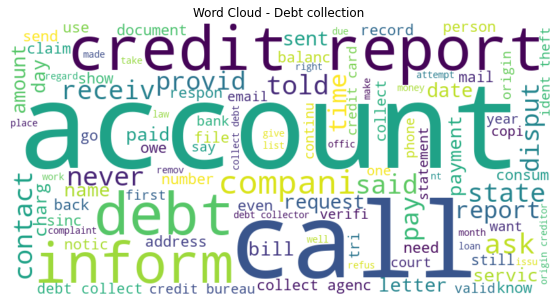

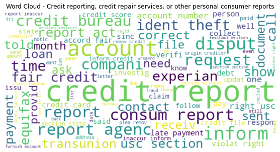

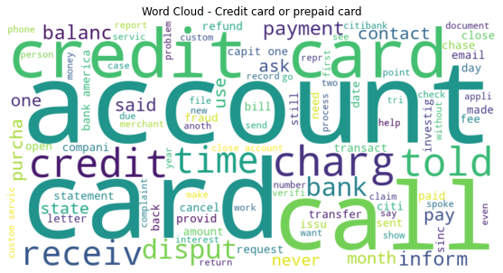

```python
# Gruppo per prodotto
products = filtered_df['Product'].unique()

for product in products:
    # Filtra i testi associati a quel prodotto
    text = " ".join(filtered_df[filtered_df['Product'] == product]['Consumer complaint narrative'])

    # Crea la word cloud
    wordcloud = WordCloud(width=800, height=400, background_color='white', max_words=100).generate(text)

    # Mostra il grafico
    plt.figure(figsize=(10, 5))
    plt.imshow(wordcloud, interpolation='bilinear')
    plt.axis('off')
    plt.title(f"Word Cloud - {product}")
    plt.show()
```